# macroeconomics 1 notes

### **[home](https://olssonmatt.github.io/)** / **[portfolio](https://olssonmatt.github.io/portfolio.html)** / **[notes](https://olssonmatt.github.io/notes.html)** / **[contact](https://olssonmatt.github.io/contact.html)**

- introduction to macroeconomics
- nature of economics
- determination and control of national income
- money, banking and monetary policy
- macroeconomic policy
- balance of payments

# introduction to macroeconomics

- studies the overall or aggregate economy
  - economy is the area of the production, distribution and trade, as well as consumption of goods and services
- looks at the overall price levels, not individual prices
- total production in the economy, not the production by individual firms
- adjustment changes across the whole economy
- now we look to terms, definitions, and more

### employment and unemployment

- employment
  - number of adult workers (15 and up) who have jobs
- unemployment ($U$)
  - number of individuals not employed actively searching for jobs
- labour force
  - total number of people who are either employed or unemployed
- discouraged workers
  - not actively seeking employment
  - not counted as unemployment
- part-time workers
  - maybe seeking a full-time position
  - considered employed
- unemployment rate($U*$)
  - percentage of the labour force that is unemployed
  - unemployment rate $ =\frac{\# of people unemployed}{\# of people in the labour force} \times 100 $
  - unemployment rate $ = \frac{U}{LF} \times 100$
- full employment ($Y*=Y$)
  - some unemployment still exists
  - takes the form of frictional of structural
- frictional unemployment
  - caused by normal turnover of labour
  - ex. retired, quit, etc.
- structural unemployment
  - occurs because of a mismatch between available workers and jobs
- full employment
  - occurs when all unemployment is frictional and structural
  - there is no cyclical unemployment at potential GDP ($Y*$)
  - natural rate of unemployment ($U*$) exists at ($Y*$)
- unemployment ($U$) changes over the buisiness cycle
  - during recession -> $U$ is above $U*$
  - during inflations/booms -> $U$ is below $U*$
- cyclical unemployment
  - when $U > U*$ which exists at $Y*$
- seasonal unemployment
  - StatsCan seasonally adjusts figures to remove this so you can see trends clearly
- effects of unemployment
  - economic problems - loss of outut, loss of skills, etc.
  - immense human suffering - illness, breakdowns, etc.
  - social problems - homelessness, crime, etc.

### price levels, inflation, and the CPI

- price level
  - the average level at prices in the economy
- inflation
  - the rate at which the price level is changing
- consumer price index
  - the most common measure of the price level
  - based on the price of a typical consumer 'basket' of goods and services
  - CPI for the base period is always 100
  - CPI in later years price s as a ratio of the price in the base period
  - $CPI = \frac{\Sigma(P_1 Q_1)}{\Sigma(P_0 Q_0)} \times 100$
- inflation
  - inflation rate is the percentage change in the CPI
  - calculate annually typically
  - inflation rate $ = \frac{P_1 - P_0}{P_0} \times 100$
  - effects of inflation
    - money is the financial measurement
    - purchasing power of money changes with inflation (decreases)
    - real value of money changes within inflation (decreases)
    - inflation changes value of any sum that is fixed in nominal terms ($M$)
  - if inflation is fully anticipated, then financial constants would remain the same with no real effects
  - unanticipated inflation benefits those with an obligation to pay money (debts, mortgages, etc.)
    - harms those entitled to received money
  - inflation is hard to forecast accurately which adds to the uncertainty of economic life
  - just because inflationr ates fall does not mean the prices are not rising

### interest rate

- interest rate is the price of borrowing funds
- expressed as a precentage
- many interest rates mvoe together
- ex. prime rate, bank rate, etc.
- inflation affects interest rates in the nominal vs. real rates
  - nominal interest rate - the price expressed in money terms
  - real interest rate - the price expressed in purchasing power terms
  - nominal - inflation = real
- borrwing depends on a real rate of interest not the nominal

### the international economy

- foreign exchange is foreign currency
- foreign exchange markets is the market where foreign currencies are traded
- exchange rates
  - number of Canadian dollars required to purhcase a unit of foreign currency
  - the Candaian dollar price of foreign currency
- depreciation of the Canadian dollar
  - means the Canadian dollar is worth less on the foreign exchange market
  - exchange rate has increased
- internal value of the Canadian dollar
  - the purchasing power of the Canadian dollar
- external value of the Canadian dollar
  - the foreign currency price of the Canadian dollar
  - the opposite of the exchange rate
- example
  - exchange rate $ = \frac{1}{0.7755} = 1.2895$ -> 1.2895 CAD for 1 USD
  - external value $ = \frac{1}{1.2895} = 0.7755$ -> 1 CAD for 0.7755 USD
- internation trade accounted for in:
  - balance of payments - records all of international payments made for goods and services
  - trade accounts - part of the balace of payments that records transactors in goods and services (imports and exports)
- trade balance: net exports ($NX$)
  - difference between value of exports ($X$) and value of imports ($IM$)
  - $NX = X - IM$
  - trade balance is typically small, among the order of ~4% of GDP

# nature of economics

### national output

- production occurs in stages
  - many firms produce outputs that are used as inputs by other firms
- intermediate goods and services - outputs of firms that are used as inputs by other firms
- final products - outputs that are not used as inputs by any other firms

### value added

- measures each firms contribution to total output
- the amount of market value that is produced by that firm
- value added = revenue - cost of goods and services (COGS)
  - ex. a steel company buys iron ore for \$200 and produces steel that sells for \\$500
  - the value added is \$300 \\$
- total value added for a product = final selling price of the product

### gross domestic product (GDP)

- total value added into the economy
- measure of all final output that is produced in the economy, valued at market prices
- adding up added values avoids double counting
- must not add up each firms output, this would overestimate the GDP

### GDP from the expenditure side

- add up the expenditures needed to purhcase final output
- 4 expenditure categories:
  1. actual consumption expenditure ($C$)
     - expenditure on all final consumer goods and services (G&S) in a year
  2. actual gross investment expenditure ($I$)
     - expenditure on G&S not for present consumption
     - ex. new plant equipment, inventory accumulation, new residential construction, etc.
     - $I$ is used in 2 ways
       - replacement investment - maintain capital stock
       - net investment - add to capital stock
     - gross $I$ = depreciation + net $I$
     - all of gross investment included in GDP because it is new production
  3. goverment purchases of G&S ($G$)
     - does not include transfer payments
     - goverment output must be measured by cost since there is not a market price
  4. net exports ($NX = X - IM$)
     - exports ($X$) are purchases of Canadian G&S, this is a part of the total expenditure on Canadian output
     - imports ($IM$) are purchases of foreign G&S by Canadians (not spent on Canadian output)
       - gross domestic product = actual consumption expenditure + actual gross investment expenditure + goverment purchases of G&S + exports - imports
       - $GDP = C + I + G + X - IM$

### GDP from the income side

- GDP is the sum of the factor incomes + indirect taxes (net subsidies) plus depreciation
- factor incomes include
  - wages and salaries
  - interest
  - business profits
- sum of those factors incomes is net domestic income at factor cost
- to get to market prices add in 'non-factor' payments
- to move from factor prices to market prices add
  - indirect taxes and subtract subsidies
- to move from net to gross add depreciation of physical capital
- must add these back to get the true volume of production
- gross domestic product = net domestic income at factor cost + indirect taxes (less subsidies) + depreciation

### gross domestic product and gross national product

- GDP
  - measure total output produced in Canada
  - total income earned from that production
  - ex. includes profuits earned by foreigners on investments in Canada
- GNP
  - measures the total income received by Canadian residents
  - no matter where income is generate
  - ex. includes income by Canadian residents on invesments abroad
- GDP is a better measure of domestic economic activity
- GNP is a better measure of economic well being of the countrys residents
- disposable personal income (DPI) is the gross national product less any part not actually paid to the household
  - personal income taces paid by household
  - transfer payments received by household

### real and nominal GDP

- total GDP valued at current prices is nominal GDP
- GDP at constant (base year) prices is real GDP
- convet from nominal to real GDP using a GDP deflator
- GDP Deflator $ = \frac{GDP at current price}{GDP at base year} \times 100 = \frac{Nominal GDP}{Real GDP} \times 100$

### GDP deflator

- most comprehensive price index
- incldues prices of all goods and services produced in the country
- cannot use a fixed basket of goods
- G&S produced change in each year
- CPI and GDP deflator move together
  - some inflationary forces affect both of them
- CPI tracks consumer prices
- GDP deflator tracks prices of all G&S in Canada
- differences
  - if the world price of coffee increased, CPI is increased
  - since Canada produces no coffee, that has no effect on the GDP deflator

### limitations and omitions from the GDP

- GDP does not measure economic activity outside of the regular and legal market
  - illegal activities (drugs, prostitution)
  - the underground economy (tax-avoided transactions)
  - home production (housework, DIY projects)
  - economic bads (pollution)
- are salaries of cops bad? - is it just an offset to the bad (criminals)?
- GDP does nt measure all aspects of human welfare

### living standards: output and productivity

- real GDP increased over the post century for 2 reasons:
  1. an increase in inputs - land, labour, and capital used in production
  2. an increase in the amount of output produced per unit of input
- per capita output is the output per person ($\frac{GDP}{population}$)
  - measures the average output or income per person
- per capita is a good measure of changes in average standard of living
- income is an important part of well-being
  - GDP is a very good measure of income
  - changes in GDP is a good measure in economic well-being
  - as long as immeasured economic activity changes a little
- labour productivity $ = \frac{GDP}{total number of hours worked}$
  - changes in labour productivity better measures changes in overall living standards than changes in GDP per capita
- this is only a part of overall well-being
- other factors may contribute to quality of life (health, security, environment, etc.)

```
[0, 1, 2, 3, 4, 5, 6, 7, 8, 9, 10, 11, 12, 13, 14, 15]
[ 0.          1.84147098  2.90929743  3.14112001  3.2431975   4.04107573
  5.7205845   7.6569866   8.98935825  9.41211849  9.45597889 10.00000979
 11.46342708 13.42016704 14.99060736 15.65028784]
```

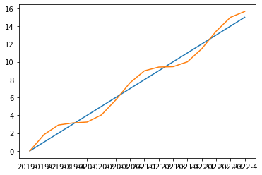

```python
import matplotlib.pyplot as plt
import numpy as np

years = ['2019','2020','2021','2022']
quarters = ['1','2','3','4']
hy = '-'
timekey = []
for x in years:
    for y in quarters:
        z = (x + hy + y)
        timekey.append(z)

p_GDP = list(range(0,16))
for x in p_GDP:
    a_GDP = np.sin(p_GDP)+p_GDP

print(p_GDP)
print(a_GDP)

fig, ax = plt.subplots()

ax.plot(timekey, p_GDP)
ax.plot(timekey, a_GDP)
```